# Risk Factor Analysis

## Outcome Variable

**Outcome Variable:** ever_stunted

## Predictor Variables

**Intervention Variable:** earlybf

**Adjustment Set:**

- arm
- sex
- W_mage
- meducyrs
- feducyrs
- hhwealth_quart
- hfoodsec
- W_mhtcm
- vagbrth
- W_birthwt
- W_birthlen
- W_nrooms
- W_nchldlt5
- brthmon
- W_parity
- impfloor
- impsan
- safeh20
- delta_W_mage
- delta_meducyrs
- delta_feducyrs
- delta_hhwealth_quart
- delta_hfoodsec
- delta_W_mhtcm
- delta_vagbrth
- delta_W_birthwt
- delta_W_birthlen
- delta_W_nrooms
- delta_W_nchldlt5
- delta_brthmon
- delta_W_parity
- delta_impfloor
- delta_impsan
- delta_safeh20

## Stratifying Variables

The analysis was stratified on these variable(s):

- agecat
- studyid
- country

## Data Summary

| agecat | studyid | country | earlybf | ever_stunted | n_cell | n |
| --- | --- | --- | --- | --- | --- | --- |
| 0-6 months | ki0047075b-MAL-ED | BANGLADESH | 0 | 0 | 78 | 264 |
| 0-6 months | ki0047075b-MAL-ED | BANGLADESH | 0 | 1 | 23 | 264 |
| 0-6 months | ki0047075b-MAL-ED | BANGLADESH | 1 | 0 | 138 | 264 |
| 0-6 months | ki0047075b-MAL-ED | BANGLADESH | 1 | 1 | 25 | 264 |
| 0-6 months | ki0047075b-MAL-ED | BRAZIL | 0 | 0 | 108 | 233 |
| 0-6 months | ki0047075b-MAL-ED | BRAZIL | 0 | 1 | 17 | 233 |
| 0-6 months | ki0047075b-MAL-ED | BRAZIL | 1 | 0 | 100 | 233 |
| 0-6 months | ki0047075b-MAL-ED | BRAZIL | 1 | 1 | 8 | 233 |
| 0-6 months | ki0047075b-MAL-ED | INDIA | 0 | 0 | 80 | 250 |
| 0-6 months | ki0047075b-MAL-ED | INDIA | 0 | 1 | 22 | 250 |
| 0-6 months | ki0047075b-MAL-ED | INDIA | 1 | 0 | 128 | 250 |
| 0-6 months | ki0047075b-MAL-ED | INDIA | 1 | 1 | 20 | 250 |
| 0-6 months | ki0047075b-MAL-ED | NEPAL | 0 | 0 | 122 | 240 |
| 0-6 months | ki0047075b-MAL-ED | NEPAL | 0 | 1 | 20 | 240 |
| 0-6 months | ki0047075b-MAL-ED | NEPAL | 1 | 0 | 90 | 240 |
| 0-6 months | ki0047075b-MAL-ED | NEPAL | 1 | 1 | 8 | 240 |
| 0-6 months | ki0047075b-MAL-ED | PERU | 0 | 0 | 64 | 303 |
| 0-6 months | ki0047075b-MAL-ED | PERU | 0 | 1 | 14 | 303 |
| 0-6 months | ki0047075b-MAL-ED | PERU | 1 | 0 | 202 | 303 |
| 0-6 months | ki0047075b-MAL-ED | PERU | 1 | 1 | 23 | 303 |
| 0-6 months | ki0047075b-MAL-ED | SOUTH AFRICA | 0 | 0 | 98 | 297 |
| 0-6 months | ki0047075b-MAL-ED | SOUTH AFRICA | 0 | 1 | 18 | 297 |
| 0-6 months | ki0047075b-MAL-ED | SOUTH AFRICA | 1 | 0 | 167 | 297 |
| 0-6 months | ki0047075b-MAL-ED | SOUTH AFRICA | 1 | 1 | 14 | 297 |
| 0-6 months | ki0047075b-MAL-ED | TANZANIA, UNITED REPUBLIC OF | 0 | 0 | 35 | 262 |
| 0-6 months | ki0047075b-MAL-ED | TANZANIA, UNITED REPUBLIC OF | 0 | 1 | 10 | 262 |
| 0-6 months | ki0047075b-MAL-ED | TANZANIA, UNITED REPUBLIC OF | 1 | 0 | 184 | 262 |
| 0-6 months | ki0047075b-MAL-ED | TANZANIA, UNITED REPUBLIC OF | 1 | 1 | 33 | 262 |
| 0-6 months | ki1000109-EE | PAKISTAN | 0 | 0 | 200 | 379 |
| 0-6 months | ki1000109-EE | PAKISTAN | 0 | 1 | 110 | 379 |

[output cut: 138 more lines]

The following strata were considered:

- agecat: 0-24 months, studyid: ki0047075b-MAL-ED, country: BANGLADESH
- agecat: 0-24 months, studyid: ki0047075b-MAL-ED, country: BRAZIL
- agecat: 0-24 months, studyid: ki0047075b-MAL-ED, country: INDIA
- agecat: 0-24 months, studyid: ki0047075b-MAL-ED, country: NEPAL
- agecat: 0-24 months, studyid: ki0047075b-MAL-ED, country: PERU
- agecat: 0-24 months, studyid: ki0047075b-MAL-ED, country: SOUTH AFRICA
- agecat: 0-24 months, studyid: ki0047075b-MAL-ED, country: TANZANIA, UNITED REPUBLIC OF
- agecat: 0-24 months, studyid: ki1000109-EE, country: PAKISTAN
- agecat: 0-24 months, studyid: ki1000304b-SAS-CompFeed, country: INDIA
- agecat: 0-24 months, studyid: ki1017093c-NIH-Crypto, country: BANGLADESH
- agecat: 0-24 months, studyid: ki1113344-GMS-Nepal, country: NEPAL
- agecat: 0-24 months, studyid: ki1126311-ZVITAMBO, country: ZIMBABWE
- agecat: 0-24 months, studyid: kiGH5241-JiVitA-3, country: BANGLADESH
- agecat: 0-24 months, studyid: kiGH5241-JiVitA-4, country: BANGLADESH
- agecat: 0-6 months, studyid: ki0047075b-MAL-ED, country: BANGLADESH
- agecat: 0-6 months, studyid: ki0047075b-MAL-ED, country: BRAZIL
- agecat: 0-6 months, studyid: ki0047075b-MAL-ED, country: INDIA
- agecat: 0-6 months, studyid: ki0047075b-MAL-ED, country: NEPAL
- agecat: 0-6 months, studyid: ki0047075b-MAL-ED, country: PERU
- agecat: 0-6 months, studyid: ki0047075b-MAL-ED, country: SOUTH AFRICA
- agecat: 0-6 months, studyid: ki0047075b-MAL-ED, country: TANZANIA, UNITED REPUBLIC OF
- agecat: 0-6 months, studyid: ki1000109-EE, country: PAKISTAN
- agecat: 0-6 months, studyid: ki1000304b-SAS-CompFeed, country: INDIA
- agecat: 0-6 months, studyid: ki1017093c-NIH-Crypto, country: BANGLADESH
- agecat: 0-6 months, studyid: ki1113344-GMS-Nepal, country: NEPAL
- agecat: 0-6 months, studyid: ki1126311-ZVITAMBO, country: ZIMBABWE
- agecat: 0-6 months, studyid: kiGH5241-JiVitA-3, country: BANGLADESH
- agecat: 0-6 months, studyid: kiGH5241-JiVitA-4, country: BANGLADESH
- agecat: 6-24 months, studyid: ki0047075b-MAL-ED, country: BANGLADESH
- agecat: 6-24 months, studyid: ki0047075b-MAL-ED, country: BRAZIL
- agecat: 6-24 months, studyid: ki0047075b-MAL-ED, country: INDIA
- agecat: 6-24 months, studyid: ki0047075b-MAL-ED, country: NEPAL
- agecat: 6-24 months, studyid: ki0047075b-MAL-ED, country: PERU
- agecat: 6-24 months, studyid: ki0047075b-MAL-ED, country: SOUTH AFRICA
- agecat: 6-24 months, studyid: ki0047075b-MAL-ED, country: TANZANIA, UNITED REPUBLIC OF
- agecat: 6-24 months, studyid: ki1000109-EE, country: PAKISTAN
- agecat: 6-24 months, studyid: ki1000304b-SAS-CompFeed, country: INDIA
- agecat: 6-24 months, studyid: ki1017093c-NIH-Crypto, country: BANGLADESH
- agecat: 6-24 months, studyid: ki1113344-GMS-Nepal, country: NEPAL
- agecat: 6-24 months, studyid: ki1126311-ZVITAMBO, country: ZIMBABWE
- agecat: 6-24 months, studyid: kiGH5241-JiVitA-3, country: BANGLADESH
- agecat: 6-24 months, studyid: kiGH5241-JiVitA-4, country: BANGLADESH

### Dropped Strata

Some strata were dropped due to rare outcomes:

- agecat: 6-24 months, studyid: ki0047075b-MAL-ED, country: BRAZIL
- agecat: 6-24 months, studyid: kiGH5241-JiVitA-3, country: BANGLADESH

## Methods Detail

We’re interested in the causal parameters $E[Y_a]$ for all values of $a \in \mathcal{A}$. These parameters represent the mean outcome if, possibly contrary to fact, we intervened to set all units to have $A=a$. Under the randomization and positivity assumptions, these are identified by the statistical parameters $\psi_a=E_W[E_{Y|A,W}(Y|A=a,W)]$. In addition, we’re interested in the mean of $Y$, $E[Y]$ under no intervention (the observed mean). We will estimate these parameters by using SuperLearner to fit the relevant likelihood factors – $E_{Y|A,W}(Y|A=a,W)$ and $p(A=a|W)$, and then updating our likelihood fit using a joint TMLE.

For unadjusted analyses ($W=\{\}$), initial likelihoods were estimated using Lrnr_glm to estimate the simple $E(Y|A)$ and Lrnr_mean to estimate $p(A)$. For adjusted analyses, a small library containing Lrnr_glmnet, Lrnr_xgboost, and Lrnr_mean was used.

Having estimated these parameters, we will then use the delta method to estimate relative risks and attributable risks relative to a prespecified baseline level of $A$.

# Results Detail

## Results Plots

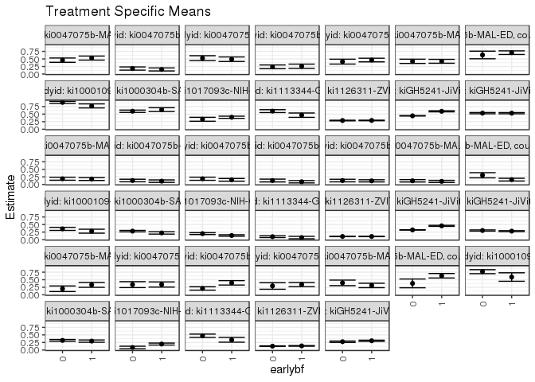

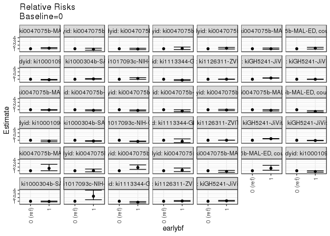

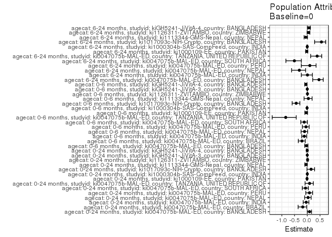

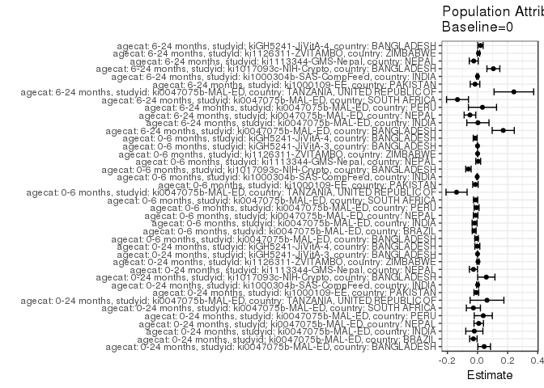

## Results Table

### Parameter: TSM

| agecat | studyid | country | intervention_level | baseline_level | estimate | ci_lower | ci_upper |
| --- | --- | --- | --- | --- | --- | --- | --- |
| 0-24 months | ki0047075b-MAL-ED | BANGLADESH | 0 | NA | 0.4594685 | 0.3885417 | 0.5303954 |
| 0-24 months | ki0047075b-MAL-ED | BANGLADESH | 1 | NA | 0.5283745 | 0.4620733 | 0.5946757 |
| 0-24 months | ki0047075b-MAL-ED | BRAZIL | 0 | NA | 0.1819774 | 0.1295021 | 0.2344528 |
| 0-24 months | ki0047075b-MAL-ED | BRAZIL | 1 | NA | 0.1514240 | 0.1018022 | 0.2010458 |
| 0-24 months | ki0047075b-MAL-ED | INDIA | 0 | NA | 0.5251559 | 0.4434663 | 0.6068454 |
| 0-24 months | ki0047075b-MAL-ED | INDIA | 1 | NA | 0.4904536 | 0.4155494 | 0.5653578 |
| 0-24 months | ki0047075b-MAL-ED | NEPAL | 0 | NA | 0.2377863 | 0.1755694 | 0.3000033 |
| 0-24 months | ki0047075b-MAL-ED | NEPAL | 1 | NA | 0.2568103 | 0.1857220 | 0.3278986 |
| 0-24 months | ki0047075b-MAL-ED | PERU | 0 | NA | 0.4106044 | 0.3298466 | 0.4913621 |
| 0-24 months | ki0047075b-MAL-ED | PERU | 1 | NA | 0.4630227 | 0.4028398 | 0.5232057 |
| 0-24 months | ki0047075b-MAL-ED | SOUTH AFRICA | 0 | NA | 0.4213199 | 0.3508804 | 0.4917594 |
| 0-24 months | ki0047075b-MAL-ED | SOUTH AFRICA | 1 | NA | 0.4214993 | 0.3571636 | 0.4858350 |
| 0-24 months | ki0047075b-MAL-ED | TANZANIA, UNITED REPUBLIC OF | 0 | NA | 0.6316871 | 0.5055520 | 0.7578222 |
| 0-24 months | ki0047075b-MAL-ED | TANZANIA, UNITED REPUBLIC OF | 1 | NA | 0.7075122 | 0.6474786 | 0.7675457 |
| 0-24 months | ki1000109-EE | PAKISTAN | 0 | NA | 0.8890569 | 0.8549471 | 0.9231667 |
| 0-24 months | ki1000109-EE | PAKISTAN | 1 | NA | 0.7720569 | 0.7044724 | 0.8396413 |
| 0-24 months | ki1000304b-SAS-CompFeed | INDIA | 0 | NA | 0.5956832 | 0.5576710 | 0.6336954 |
| 0-24 months | ki1000304b-SAS-CompFeed | INDIA | 1 | NA | 0.6488169 | 0.5853713 | 0.7122625 |
| 0-24 months | ki1017093c-NIH-Crypto | BANGLADESH | 0 | NA | 0.3294599 | 0.2643610 | 0.3945588 |
| 0-24 months | ki1017093c-NIH-Crypto | BANGLADESH | 1 | NA | 0.3967386 | 0.3604909 | 0.4329863 |
| 0-24 months | ki1113344-GMS-Nepal | NEPAL | 0 | NA | 0.5999012 | 0.5519652 | 0.6478372 |
| 0-24 months | ki1113344-GMS-Nepal | NEPAL | 1 | NA | 0.4656193 | 0.3942831 | 0.5369555 |
| 0-24 months | ki1126311-ZVITAMBO | ZIMBABWE | 0 | NA | 0.2878165 | 0.2777525 | 0.2978805 |
| 0-24 months | ki1126311-ZVITAMBO | ZIMBABWE | 1 | NA | 0.2908885 | 0.2812518 | 0.3005252 |
| 0-24 months | kiGH5241-JiVitA-3 | BANGLADESH | 0 | NA | 0.4442306 | 0.4367005 | 0.4517607 |
| 0-24 months | kiGH5241-JiVitA-3 | BANGLADESH | 1 | NA | 0.5933833 | 0.5745018 | 0.6122648 |
| 0-24 months | kiGH5241-JiVitA-4 | BANGLADESH | 0 | NA | 0.5327471 | 0.5116084 | 0.5538858 |
| 0-24 months | kiGH5241-JiVitA-4 | BANGLADESH | 1 | NA | 0.5313786 | 0.5115964 | 0.5511608 |
| 0-6 months | ki0047075b-MAL-ED | BANGLADESH | 0 | NA | 0.1881150 | 0.1385136 | 0.2377164 |
| 0-6 months | ki0047075b-MAL-ED | BANGLADESH | 1 | NA | 0.1776253 | 0.1314890 | 0.2237616 |
| 0-6 months | ki0047075b-MAL-ED | BRAZIL | 0 | NA | 0.1296567 | 0.0872384 | 0.1720750 |
| 0-6 months | ki0047075b-MAL-ED | BRAZIL | 1 | NA | 0.1088832 | 0.0684087 | 0.1493577 |
| 0-6 months | ki0047075b-MAL-ED | INDIA | 0 | NA | 0.1874684 | 0.1354359 | 0.2395010 |
| 0-6 months | ki0047075b-MAL-ED | INDIA | 1 | NA | 0.1517788 | 0.1070724 | 0.1964853 |
| 0-6 months | ki0047075b-MAL-ED | NEPAL | 0 | NA | 0.1291420 | 0.0825803 | 0.1757037 |
| 0-6 months | ki0047075b-MAL-ED | NEPAL | 1 | NA | 0.0882151 | 0.0493042 | 0.1271259 |
| 0-6 months | ki0047075b-MAL-ED | PERU | 0 | NA | 0.1282999 | 0.0854607 | 0.1711392 |
| 0-6 months | ki0047075b-MAL-ED | PERU | 1 | NA | 0.1186213 | 0.0823575 | 0.1548851 |
| 0-6 months | ki0047075b-MAL-ED | SOUTH AFRICA | 0 | NA | 0.1204714 | 0.0804737 | 0.1604691 |
| 0-6 months | ki0047075b-MAL-ED | SOUTH AFRICA | 1 | NA | 0.1012851 | 0.0667437 | 0.1358264 |
| 0-6 months | ki0047075b-MAL-ED | TANZANIA, UNITED REPUBLIC OF | 0 | NA | 0.3032494 | 0.2167643 | 0.3897345 |
| 0-6 months | ki0047075b-MAL-ED | TANZANIA, UNITED REPUBLIC OF | 1 | NA | 0.1581531 | 0.1124419 | 0.2038644 |
| 0-6 months | ki1000109-EE | PAKISTAN | 0 | NA | 0.3567830 | 0.3055931 | 0.4079730 |
| 0-6 months | ki1000109-EE | PAKISTAN | 1 | NA | 0.2785173 | 0.2133198 | 0.3437148 |
| 0-6 months | ki1000304b-SAS-CompFeed | INDIA | 0 | NA | 0.2806758 | 0.2559408 | 0.3054108 |
| 0-6 months | ki1000304b-SAS-CompFeed | INDIA | 1 | NA | 0.2218629 | 0.1827064 | 0.2610194 |
| 0-6 months | ki1017093c-NIH-Crypto | BANGLADESH | 0 | NA | 0.1987143 | 0.1683451 | 0.2290835 |
| 0-6 months | ki1017093c-NIH-Crypto | BANGLADESH | 1 | NA | 0.1367554 | 0.1122243 | 0.1612864 |
| 0-6 months | ki1113344-GMS-Nepal | NEPAL | 0 | NA | 0.0976258 | 0.0677806 | 0.1274710 |
| 0-6 months | ki1113344-GMS-Nepal | NEPAL | 1 | NA | 0.0679736 | 0.0272705 | 0.1086766 |
| 0-6 months | ki1126311-ZVITAMBO | ZIMBABWE | 0 | NA | 0.1039313 | 0.0985721 | 0.1092904 |
| 0-6 months | ki1126311-ZVITAMBO | ZIMBABWE | 1 | NA | 0.1038692 | 0.0985196 | 0.1092188 |
| 0-6 months | kiGH5241-JiVitA-3 | BANGLADESH | 0 | NA | 0.3218403 | 0.3150707 | 0.3286100 |
| 0-6 months | kiGH5241-JiVitA-3 | BANGLADESH | 1 | NA | 0.4568314 | 0.4400843 | 0.4735786 |
| 0-6 months | kiGH5241-JiVitA-4 | BANGLADESH | 0 | NA | 0.3021510 | 0.2828504 | 0.3214516 |
| 0-6 months | kiGH5241-JiVitA-4 | BANGLADESH | 1 | NA | 0.2807115 | 0.2656353 | 0.2957878 |
| 6-24 months | ki0047075b-MAL-ED | BANGLADESH | 0 | NA | 0.2004370 | 0.1081923 | 0.2926817 |
| 6-24 months | ki0047075b-MAL-ED | BANGLADESH | 1 | NA | 0.3300244 | 0.2482803 | 0.4117684 |
| 6-24 months | ki0047075b-MAL-ED | INDIA | 0 | NA | 0.3375985 | 0.2398422 | 0.4353547 |
| 6-24 months | ki0047075b-MAL-ED | INDIA | 1 | NA | 0.3420209 | 0.2561671 | 0.4278748 |
| 6-24 months | ki0047075b-MAL-ED | NEPAL | 0 | NA | 0.2108378 | 0.1548272 | 0.2668483 |
| 6-24 months | ki0047075b-MAL-ED | NEPAL | 1 | NA | 0.3966467 | 0.3241303 | 0.4691630 |
| 6-24 months | ki0047075b-MAL-ED | PERU | 0 | NA | 0.2945267 | 0.1852266 | 0.4038268 |
| 6-24 months | ki0047075b-MAL-ED | PERU | 1 | NA | 0.3391795 | 0.2690677 | 0.4092912 |
| 6-24 months | ki0047075b-MAL-ED | SOUTH AFRICA | 0 | NA | 0.3953893 | 0.3035451 | 0.4872334 |
| 6-24 months | ki0047075b-MAL-ED | SOUTH AFRICA | 1 | NA | 0.3104159 | 0.2365261 | 0.3843057 |
| 6-24 months | ki0047075b-MAL-ED | TANZANIA, UNITED REPUBLIC OF | 0 | NA | 0.3788892 | 0.2334773 | 0.5243010 |
| 6-24 months | ki0047075b-MAL-ED | TANZANIA, UNITED REPUBLIC OF | 1 | NA | 0.6312015 | 0.5572447 | 0.7051582 |
| 6-24 months | ki1000109-EE | PAKISTAN | 0 | NA | 0.7665045 | 0.7002221 | 0.8327869 |
| 6-24 months | ki1000109-EE | PAKISTAN | 1 | NA | 0.5887225 | 0.4483030 | 0.7291419 |
| 6-24 months | ki1000304b-SAS-CompFeed | INDIA | 0 | NA | 0.3187169 | 0.2891100 | 0.3483238 |
| 6-24 months | ki1000304b-SAS-CompFeed | INDIA | 1 | NA | 0.2954010 | 0.2580137 | 0.3327883 |
| 6-24 months | ki1017093c-NIH-Crypto | BANGLADESH | 0 | NA | 0.0834083 | 0.0410966 | 0.1257200 |
| 6-24 months | ki1017093c-NIH-Crypto | BANGLADESH | 1 | NA | 0.1974133 | 0.1642545 | 0.2305721 |
| 6-24 months | ki1113344-GMS-Nepal | NEPAL | 0 | NA | 0.4724904 | 0.4172320 | 0.5277488 |
| 6-24 months | ki1113344-GMS-Nepal | NEPAL | 1 | NA | 0.3386366 | 0.2595750 | 0.4176982 |
| 6-24 months | ki1126311-ZVITAMBO | ZIMBABWE | 0 | NA | 0.1271966 | 0.1171456 | 0.1372477 |
| 6-24 months | ki1126311-ZVITAMBO | ZIMBABWE | 1 | NA | 0.1362792 | 0.1267772 | 0.1457811 |
| 6-24 months | kiGH5241-JiVitA-4 | BANGLADESH | 0 | NA | 0.2753934 | 0.2534584 | 0.2973284 |
| 6-24 months | kiGH5241-JiVitA-4 | BANGLADESH | 1 | NA | 0.3062404 | 0.2858446 | 0.3266361 |

### Parameter: E(Y)

| agecat | studyid | country | intervention_level | baseline_level | estimate | ci_lower | ci_upper |
| --- | --- | --- | --- | --- | --- | --- | --- |
| 0-24 months | ki0047075b-MAL-ED | BANGLADESH | NA | NA | 0.5037879 | 0.4433613 | 0.5642144 |
| 0-24 months | ki0047075b-MAL-ED | BRAZIL | NA | NA | 0.1545064 | 0.1079979 | 0.2010150 |
| 0-24 months | ki0047075b-MAL-ED | INDIA | NA | NA | 0.5040000 | 0.4418982 | 0.5661018 |
| 0-24 months | ki0047075b-MAL-ED | NEPAL | NA | NA | 0.2458333 | 0.1912446 | 0.3004221 |
| 0-24 months | ki0047075b-MAL-ED | PERU | NA | NA | 0.4488449 | 0.3927492 | 0.5049406 |
| 0-24 months | ki0047075b-MAL-ED | SOUTH AFRICA | NA | NA | 0.3939394 | 0.3382753 | 0.4496035 |
| 0-24 months | ki0047075b-MAL-ED | TANZANIA, UNITED REPUBLIC OF | NA | NA | 0.6946565 | 0.6387828 | 0.7505302 |
| 0-24 months | ki1000109-EE | PAKISTAN | NA | NA | 0.8812665 | 0.8486571 | 0.9138759 |
| 0-24 months | ki1000304b-SAS-CompFeed | INDIA | NA | NA | 0.5966102 | 0.5576528 | 0.6355676 |
| 0-24 months | ki1017093c-NIH-Crypto | BANGLADESH | NA | NA | 0.3878628 | 0.3531521 | 0.4225735 |
| 0-24 months | ki1113344-GMS-Nepal | NEPAL | NA | NA | 0.5729927 | 0.5315406 | 0.6144448 |
| 0-24 months | ki1126311-ZVITAMBO | ZIMBABWE | NA | NA | 0.2912211 | 0.2832658 | 0.2991764 |
| 0-24 months | kiGH5241-JiVitA-3 | BANGLADESH | NA | NA | 0.4443380 | 0.4368301 | 0.4518459 |
| 0-24 months | kiGH5241-JiVitA-4 | BANGLADESH | NA | NA | 0.5316060 | 0.5154292 | 0.5477829 |
| 0-6 months | ki0047075b-MAL-ED | BANGLADESH | NA | NA | 0.1818182 | 0.1352045 | 0.2284319 |
| 0-6 months | ki0047075b-MAL-ED | BRAZIL | NA | NA | 0.1072961 | 0.0674717 | 0.1471206 |
| 0-6 months | ki0047075b-MAL-ED | INDIA | NA | NA | 0.1680000 | 0.1215629 | 0.2144371 |
| 0-6 months | ki0047075b-MAL-ED | NEPAL | NA | NA | 0.1166667 | 0.0759676 | 0.1573658 |
| 0-6 months | ki0047075b-MAL-ED | PERU | NA | NA | 0.1221122 | 0.0851852 | 0.1590392 |
| 0-6 months | ki0047075b-MAL-ED | SOUTH AFRICA | NA | NA | 0.1077441 | 0.0724222 | 0.1430660 |
| 0-6 months | ki0047075b-MAL-ED | TANZANIA, UNITED REPUBLIC OF | NA | NA | 0.1641221 | 0.1191873 | 0.2090569 |
| 0-6 months | ki1000109-EE | PAKISTAN | NA | NA | 0.3430079 | 0.2951521 | 0.3908637 |
| 0-6 months | ki1000304b-SAS-CompFeed | INDIA | NA | NA | 0.2785326 | 0.2525203 | 0.3045449 |
| 0-6 months | ki1017093c-NIH-Crypto | BANGLADESH | NA | NA | 0.1385224 | 0.1139141 | 0.1631308 |
| 0-6 months | ki1113344-GMS-Nepal | NEPAL | NA | NA | 0.1021898 | 0.0768063 | 0.1275732 |
| 0-6 months | ki1126311-ZVITAMBO | ZIMBABWE | NA | NA | 0.1046363 | 0.0992724 | 0.1100002 |
| 0-6 months | kiGH5241-JiVitA-3 | BANGLADESH | NA | NA | 0.3219932 | 0.3152366 | 0.3287498 |
| 0-6 months | kiGH5241-JiVitA-4 | BANGLADESH | NA | NA | 0.2867446 | 0.2729319 | 0.3005573 |
| 6-24 months | ki0047075b-MAL-ED | BANGLADESH | NA | NA | 0.3711340 | 0.3029765 | 0.4392916 |
| 6-24 months | ki0047075b-MAL-ED | INDIA | NA | NA | 0.3402062 | 0.2733649 | 0.4070475 |
| 6-24 months | ki0047075b-MAL-ED | NEPAL | NA | NA | 0.1607143 | 0.1125109 | 0.2089177 |
| 6-24 months | ki0047075b-MAL-ED | PERU | NA | NA | 0.3275109 | 0.2665942 | 0.3884276 |
| 6-24 months | ki0047075b-MAL-ED | SOUTH AFRICA | NA | NA | 0.2624434 | 0.2043065 | 0.3205804 |
| 6-24 months | ki0047075b-MAL-ED | TANZANIA, UNITED REPUBLIC OF | NA | NA | 0.6203209 | 0.5505766 | 0.6900651 |
| 6-24 months | ki1000109-EE | PAKISTAN | NA | NA | 0.7500000 | 0.6879377 | 0.8120623 |
| 6-24 months | ki1000304b-SAS-CompFeed | INDIA | NA | NA | 0.3184647 | 0.2882909 | 0.3486385 |
| 6-24 months | ki1017093c-NIH-Crypto | BANGLADESH | NA | NA | 0.1887097 | 0.1578857 | 0.2195336 |
| 6-24 months | ki1113344-GMS-Nepal | NEPAL | NA | NA | 0.4474886 | 0.4008689 | 0.4941082 |
| 6-24 months | ki1126311-ZVITAMBO | ZIMBABWE | NA | NA | 0.1338488 | 0.1265135 | 0.1411840 |
| 6-24 months | kiGH5241-JiVitA-4 | BANGLADESH | NA | NA | 0.2949907 | 0.2786334 | 0.3113480 |

### Parameter: RR

| agecat | studyid | country | intervention_level | baseline_level | estimate | ci_lower | ci_upper |
| --- | --- | --- | --- | --- | --- | --- | --- |
| 0-24 months | ki0047075b-MAL-ED | BANGLADESH | 0 | 0 | 1.0000000 | 1.0000000 | 1.0000000 |
| 0-24 months | ki0047075b-MAL-ED | BANGLADESH | 1 | 0 | 1.1499689 | 0.9996383 | 1.3229069 |
| 0-24 months | ki0047075b-MAL-ED | BRAZIL | 0 | 0 | 1.0000000 | 1.0000000 | 1.0000000 |
| 0-24 months | ki0047075b-MAL-ED | BRAZIL | 1 | 0 | 0.8321032 | 0.6065491 | 1.1415330 |
| 0-24 months | ki0047075b-MAL-ED | INDIA | 0 | 0 | 1.0000000 | 1.0000000 | 1.0000000 |
| 0-24 months | ki0047075b-MAL-ED | INDIA | 1 | 0 | 0.9339200 | 0.7736483 | 1.1273942 |
| 0-24 months | ki0047075b-MAL-ED | NEPAL | 0 | 0 | 1.0000000 | 1.0000000 | 1.0000000 |
| 0-24 months | ki0047075b-MAL-ED | NEPAL | 1 | 0 | 1.0800045 | 0.7940658 | 1.4689082 |
| 0-24 months | ki0047075b-MAL-ED | PERU | 0 | 0 | 1.0000000 | 1.0000000 | 1.0000000 |
| 0-24 months | ki0047075b-MAL-ED | PERU | 1 | 0 | 1.1276616 | 0.9312475 | 1.3655023 |
| 0-24 months | ki0047075b-MAL-ED | SOUTH AFRICA | 0 | 0 | 1.0000000 | 1.0000000 | 1.0000000 |
| 0-24 months | ki0047075b-MAL-ED | SOUTH AFRICA | 1 | 0 | 1.0004258 | 0.8326693 | 1.2019799 |
| 0-24 months | ki0047075b-MAL-ED | TANZANIA, UNITED REPUBLIC OF | 0 | 0 | 1.0000000 | 1.0000000 | 1.0000000 |
| 0-24 months | ki0047075b-MAL-ED | TANZANIA, UNITED REPUBLIC OF | 1 | 0 | 1.1200358 | 0.9070692 | 1.3830039 |
| 0-24 months | ki1000109-EE | PAKISTAN | 0 | 0 | 1.0000000 | 1.0000000 | 1.0000000 |
| 0-24 months | ki1000109-EE | PAKISTAN | 1 | 0 | 0.8683998 | 0.7911042 | 0.9532477 |
| 0-24 months | ki1000304b-SAS-CompFeed | INDIA | 0 | 0 | 1.0000000 | 1.0000000 | 1.0000000 |
| 0-24 months | ki1000304b-SAS-CompFeed | INDIA | 1 | 0 | 1.0891979 | 0.9941420 | 1.1933426 |
| 0-24 months | ki1017093c-NIH-Crypto | BANGLADESH | 0 | 0 | 1.0000000 | 1.0000000 | 1.0000000 |
| 0-24 months | ki1017093c-NIH-Crypto | BANGLADESH | 1 | 0 | 1.2042091 | 0.9895284 | 1.4654652 |
| 0-24 months | ki1113344-GMS-Nepal | NEPAL | 0 | 0 | 1.0000000 | 1.0000000 | 1.0000000 |
| 0-24 months | ki1113344-GMS-Nepal | NEPAL | 1 | 0 | 0.7761601 | 0.6530719 | 0.9224474 |
| 0-24 months | ki1126311-ZVITAMBO | ZIMBABWE | 0 | 0 | 1.0000000 | 1.0000000 | 1.0000000 |
| 0-24 months | ki1126311-ZVITAMBO | ZIMBABWE | 1 | 0 | 1.0106735 | 0.9693982 | 1.0537063 |
| 0-24 months | kiGH5241-JiVitA-3 | BANGLADESH | 0 | 0 | 1.0000000 | 1.0000000 | 1.0000000 |
| 0-24 months | kiGH5241-JiVitA-3 | BANGLADESH | 1 | 0 | 1.3357551 | 1.2916910 | 1.3813223 |
| 0-24 months | kiGH5241-JiVitA-4 | BANGLADESH | 0 | 0 | 1.0000000 | 1.0000000 | 1.0000000 |
| 0-24 months | kiGH5241-JiVitA-4 | BANGLADESH | 1 | 0 | 0.9974311 | 0.9496421 | 1.0476251 |
| 0-6 months | ki0047075b-MAL-ED | BANGLADESH | 0 | 0 | 1.0000000 | 1.0000000 | 1.0000000 |
| 0-6 months | ki0047075b-MAL-ED | BANGLADESH | 1 | 0 | 0.9442378 | 0.8513674 | 1.0472388 |
| 0-6 months | ki0047075b-MAL-ED | BRAZIL | 0 | 0 | 1.0000000 | 1.0000000 | 1.0000000 |
| 0-6 months | ki0047075b-MAL-ED | BRAZIL | 1 | 0 | 0.8397808 | 0.7072869 | 0.9970944 |
| 0-6 months | ki0047075b-MAL-ED | INDIA | 0 | 0 | 1.0000000 | 1.0000000 | 1.0000000 |
| 0-6 months | ki0047075b-MAL-ED | INDIA | 1 | 0 | 0.8096233 | 0.6812979 | 0.9621192 |
| 0-6 months | ki0047075b-MAL-ED | NEPAL | 0 | 0 | 1.0000000 | 1.0000000 | 1.0000000 |
| 0-6 months | ki0047075b-MAL-ED | NEPAL | 1 | 0 | 0.6830858 | 0.4748513 | 0.9826363 |
| 0-6 months | ki0047075b-MAL-ED | PERU | 0 | 0 | 1.0000000 | 1.0000000 | 1.0000000 |
| 0-6 months | ki0047075b-MAL-ED | PERU | 1 | 0 | 0.9245626 | 0.7743163 | 1.1039624 |
| 0-6 months | ki0047075b-MAL-ED | SOUTH AFRICA | 0 | 0 | 1.0000000 | 1.0000000 | 1.0000000 |
| 0-6 months | ki0047075b-MAL-ED | SOUTH AFRICA | 1 | 0 | 0.8407396 | 0.6806451 | 1.0384899 |
| 0-6 months | ki0047075b-MAL-ED | TANZANIA, UNITED REPUBLIC OF | 0 | 0 | 1.0000000 | 1.0000000 | 1.0000000 |
| 0-6 months | ki0047075b-MAL-ED | TANZANIA, UNITED REPUBLIC OF | 1 | 0 | 0.5215283 | 0.3684138 | 0.7382780 |
| 0-6 months | ki1000109-EE | PAKISTAN | 0 | 0 | 1.0000000 | 1.0000000 | 1.0000000 |
| 0-6 months | ki1000109-EE | PAKISTAN | 1 | 0 | 0.7806349 | 0.6046850 | 1.0077823 |
| 0-6 months | ki1000304b-SAS-CompFeed | INDIA | 0 | 0 | 1.0000000 | 1.0000000 | 1.0000000 |
| 0-6 months | ki1000304b-SAS-CompFeed | INDIA | 1 | 0 | 0.7904598 | 0.7105382 | 0.8793709 |
| 0-6 months | ki1017093c-NIH-Crypto | BANGLADESH | 0 | 0 | 1.0000000 | 1.0000000 | 1.0000000 |
| 0-6 months | ki1017093c-NIH-Crypto | BANGLADESH | 1 | 0 | 0.6882010 | 0.6087656 | 0.7780017 |
| 0-6 months | ki1113344-GMS-Nepal | NEPAL | 0 | 0 | 1.0000000 | 1.0000000 | 1.0000000 |
| 0-6 months | ki1113344-GMS-Nepal | NEPAL | 1 | 0 | 0.6962665 | 0.3557536 | 1.3627046 |
| 0-6 months | ki1126311-ZVITAMBO | ZIMBABWE | 0 | 0 | 1.0000000 | 1.0000000 | 1.0000000 |
| 0-6 months | ki1126311-ZVITAMBO | ZIMBABWE | 1 | 0 | 0.9994033 | 0.9899988 | 1.0088972 |
| 0-6 months | kiGH5241-JiVitA-3 | BANGLADESH | 0 | 0 | 1.0000000 | 1.0000000 | 1.0000000 |
| 0-6 months | kiGH5241-JiVitA-3 | BANGLADESH | 1 | 0 | 1.4194350 | 1.3672109 | 1.4736540 |
| 0-6 months | kiGH5241-JiVitA-4 | BANGLADESH | 0 | 0 | 1.0000000 | 1.0000000 | 1.0000000 |
| 0-6 months | kiGH5241-JiVitA-4 | BANGLADESH | 1 | 0 | 0.9290438 | 0.8688111 | 0.9934522 |
| 6-24 months | ki0047075b-MAL-ED | BANGLADESH | 0 | 0 | 1.0000000 | 1.0000000 | 1.0000000 |
| 6-24 months | ki0047075b-MAL-ED | BANGLADESH | 1 | 0 | 1.6465244 | 0.9893673 | 2.7401781 |
| 6-24 months | ki0047075b-MAL-ED | INDIA | 0 | 0 | 1.0000000 | 1.0000000 | 1.0000000 |
| 6-24 months | ki0047075b-MAL-ED | INDIA | 1 | 0 | 1.0130997 | 0.7004694 | 1.4652619 |
| 6-24 months | ki0047075b-MAL-ED | NEPAL | 0 | 0 | 1.0000000 | 1.0000000 | 1.0000000 |
| 6-24 months | ki0047075b-MAL-ED | NEPAL | 1 | 0 | 1.8812886 | 1.3693940 | 2.5845352 |
| 6-24 months | ki0047075b-MAL-ED | PERU | 0 | 0 | 1.0000000 | 1.0000000 | 1.0000000 |
| 6-24 months | ki0047075b-MAL-ED | PERU | 1 | 0 | 1.1516086 | 0.7629135 | 1.7383391 |
| 6-24 months | ki0047075b-MAL-ED | SOUTH AFRICA | 0 | 0 | 1.0000000 | 1.0000000 | 1.0000000 |
| 6-24 months | ki0047075b-MAL-ED | SOUTH AFRICA | 1 | 0 | 0.7850894 | 0.5644995 | 1.0918794 |
| 6-24 months | ki0047075b-MAL-ED | TANZANIA, UNITED REPUBLIC OF | 0 | 0 | 1.0000000 | 1.0000000 | 1.0000000 |
| 6-24 months | ki0047075b-MAL-ED | TANZANIA, UNITED REPUBLIC OF | 1 | 0 | 1.6659265 | 1.1253900 | 2.4660883 |
| 6-24 months | ki1000109-EE | PAKISTAN | 0 | 0 | 1.0000000 | 1.0000000 | 1.0000000 |
| 6-24 months | ki1000109-EE | PAKISTAN | 1 | 0 | 0.7680613 | 0.5964933 | 0.9889771 |
| 6-24 months | ki1000304b-SAS-CompFeed | INDIA | 0 | 0 | 1.0000000 | 1.0000000 | 1.0000000 |
| 6-24 months | ki1000304b-SAS-CompFeed | INDIA | 1 | 0 | 0.9268446 | 0.8194168 | 1.0483565 |
| 6-24 months | ki1017093c-NIH-Crypto | BANGLADESH | 0 | 0 | 1.0000000 | 1.0000000 | 1.0000000 |
| 6-24 months | ki1017093c-NIH-Crypto | BANGLADESH | 1 | 0 | 2.3668309 | 1.3982072 | 4.0064795 |
| 6-24 months | ki1113344-GMS-Nepal | NEPAL | 0 | 0 | 1.0000000 | 1.0000000 | 1.0000000 |
| 6-24 months | ki1113344-GMS-Nepal | NEPAL | 1 | 0 | 0.7167058 | 0.5522439 | 0.9301455 |
| 6-24 months | ki1126311-ZVITAMBO | ZIMBABWE | 0 | 0 | 1.0000000 | 1.0000000 | 1.0000000 |
| 6-24 months | ki1126311-ZVITAMBO | ZIMBABWE | 1 | 0 | 1.0714055 | 0.9659939 | 1.1883198 |
| 6-24 months | kiGH5241-JiVitA-4 | BANGLADESH | 0 | 0 | 1.0000000 | 1.0000000 | 1.0000000 |
| 6-24 months | kiGH5241-JiVitA-4 | BANGLADESH | 1 | 0 | 1.1120106 | 1.0079812 | 1.2267765 |

### Parameter: PAR

| agecat | studyid | country | intervention_level | baseline_level | estimate | ci_lower | ci_upper |
| --- | --- | --- | --- | --- | --- | --- | --- |
| 0-24 months | ki0047075b-MAL-ED | BANGLADESH | 0 | NA | 0.0443194 | 0.0023499 | 0.0862888 |
| 0-24 months | ki0047075b-MAL-ED | BRAZIL | 0 | NA | -0.0274710 | -0.0521324 | -0.0028096 |
| 0-24 months | ki0047075b-MAL-ED | INDIA | 0 | NA | -0.0211559 | -0.0778816 | 0.0355698 |
| 0-24 months | ki0047075b-MAL-ED | NEPAL | 0 | NA | 0.0080470 | -0.0232957 | 0.0393897 |
| 0-24 months | ki0047075b-MAL-ED | PERU | 0 | NA | 0.0382405 | -0.0216476 | 0.0981286 |
| 0-24 months | ki0047075b-MAL-ED | SOUTH AFRICA | 0 | NA | -0.0273805 | -0.0741007 | 0.0193397 |
| 0-24 months | ki0047075b-MAL-ED | TANZANIA, UNITED REPUBLIC OF | 0 | NA | 0.0629694 | -0.0491390 | 0.1750778 |
| 0-24 months | ki1000109-EE | PAKISTAN | 0 | NA | -0.0077904 | -0.0236911 | 0.0081103 |
| 0-24 months | ki1000304b-SAS-CompFeed | INDIA | 0 | NA | 0.0009270 | -0.0059010 | 0.0077549 |
| 0-24 months | ki1017093c-NIH-Crypto | BANGLADESH | 0 | NA | 0.0584029 | 0.0010626 | 0.1157432 |
| 0-24 months | ki1113344-GMS-Nepal | NEPAL | 0 | NA | -0.0269085 | -0.0538818 | 0.0000648 |
| 0-24 months | ki1126311-ZVITAMBO | ZIMBABWE | 0 | NA | 0.0034046 | -0.0030677 | 0.0098770 |
| 0-24 months | kiGH5241-JiVitA-3 | BANGLADESH | 0 | NA | 0.0001074 | -0.0001356 | 0.0003503 |
| 0-24 months | kiGH5241-JiVitA-4 | BANGLADESH | 0 | NA | -0.0011411 | -0.0175098 | 0.0152276 |
| 0-6 months | ki0047075b-MAL-ED | BANGLADESH | 0 | NA | -0.0062968 | -0.0181561 | 0.0055624 |
| 0-6 months | ki0047075b-MAL-ED | BRAZIL | 0 | NA | -0.0223606 | -0.0349969 | -0.0097243 |
| 0-6 months | ki0047075b-MAL-ED | INDIA | 0 | NA | -0.0194684 | -0.0358700 | -0.0030669 |
| 0-6 months | ki0047075b-MAL-ED | NEPAL | 0 | NA | -0.0124753 | -0.0277357 | 0.0027850 |
| 0-6 months | ki0047075b-MAL-ED | PERU | 0 | NA | -0.0061877 | -0.0225697 | 0.0101943 |
| 0-6 months | ki0047075b-MAL-ED | SOUTH AFRICA | 0 | NA | -0.0127273 | -0.0267125 | 0.0012579 |
| 0-6 months | ki0047075b-MAL-ED | TANZANIA, UNITED REPUBLIC OF | 0 | NA | -0.1391272 | -0.2091445 | -0.0691099 |
| 0-6 months | ki1000109-EE | PAKISTAN | 0 | NA | -0.0137751 | -0.0319002 | 0.0043500 |
| 0-6 months | ki1000304b-SAS-CompFeed | INDIA | 0 | NA | -0.0021432 | -0.0049968 | 0.0007105 |
| 0-6 months | ki1017093c-NIH-Crypto | BANGLADESH | 0 | NA | -0.0601919 | -0.0781153 | -0.0422684 |
| 0-6 months | ki1113344-GMS-Nepal | NEPAL | 0 | NA | 0.0045640 | -0.0114424 | 0.0205704 |
| 0-6 months | ki1126311-ZVITAMBO | ZIMBABWE | 0 | NA | 0.0007050 | 0.0001826 | 0.0012275 |
| 0-6 months | kiGH5241-JiVitA-3 | BANGLADESH | 0 | NA | 0.0001529 | -0.0000656 | 0.0003714 |
| 0-6 months | kiGH5241-JiVitA-4 | BANGLADESH | 0 | NA | -0.0154064 | -0.0284363 | -0.0023764 |
| 6-24 months | ki0047075b-MAL-ED | BANGLADESH | 0 | NA | 0.1706971 | 0.0973245 | 0.2440696 |
| 6-24 months | ki0047075b-MAL-ED | INDIA | 0 | NA | 0.0026077 | -0.0710139 | 0.0762293 |
| 6-24 months | ki0047075b-MAL-ED | NEPAL | 0 | NA | -0.0501235 | -0.0886905 | -0.0115564 |
| 6-24 months | ki0047075b-MAL-ED | PERU | 0 | NA | 0.0329842 | -0.0603465 | 0.1263150 |
| 6-24 months | ki0047075b-MAL-ED | SOUTH AFRICA | 0 | NA | -0.1329458 | -0.2057365 | -0.0601552 |
| 6-24 months | ki0047075b-MAL-ED | TANZANIA, UNITED REPUBLIC OF | 0 | NA | 0.2414317 | 0.1098554 | 0.3730080 |
| 6-24 months | ki1000109-EE | PAKISTAN | 0 | NA | -0.0165045 | -0.0481764 | 0.0151674 |
| 6-24 months | ki1000304b-SAS-CompFeed | INDIA | 0 | NA | -0.0002521 | -0.0056613 | 0.0051570 |
| 6-24 months | ki1017093c-NIH-Crypto | BANGLADESH | 0 | NA | 0.1053014 | 0.0623763 | 0.1482265 |
| 6-24 months | ki1113344-GMS-Nepal | NEPAL | 0 | NA | -0.0250018 | -0.0548242 | 0.0048205 |
| 6-24 months | ki1126311-ZVITAMBO | ZIMBABWE | 0 | NA | 0.0066521 | -0.0007892 | 0.0140934 |
| 6-24 months | kiGH5241-JiVitA-4 | BANGLADESH | 0 | NA | 0.0195973 | 0.0017300 | 0.0374647 |

### Parameter: PAF

| agecat | studyid | country | intervention_level | baseline_level | estimate | ci_lower | ci_upper |
| --- | --- | --- | --- | --- | --- | --- | --- |
| 0-24 months | ki0047075b-MAL-ED | BANGLADESH | 0 | NA | 0.0879722 | 0.0008802 | 0.1674726 |
| 0-24 months | ki0047075b-MAL-ED | BRAZIL | 0 | NA | -0.1777983 | -0.3592194 | -0.0205922 |
| 0-24 months | ki0047075b-MAL-ED | INDIA | 0 | NA | -0.0419759 | -0.1612903 | 0.0650798 |
| 0-24 months | ki0047075b-MAL-ED | NEPAL | 0 | NA | 0.0327336 | -0.1035616 | 0.1521957 |
| 0-24 months | ki0047075b-MAL-ED | PERU | 0 | NA | 0.0851977 | -0.0585545 | 0.2094282 |
| 0-24 months | ki0047075b-MAL-ED | SOUTH AFRICA | 0 | NA | -0.0695044 | -0.1960517 | 0.0436537 |
| 0-24 months | ki0047075b-MAL-ED | TANZANIA, UNITED REPUBLIC OF | 0 | NA | 0.0906483 | -0.0862950 | 0.2387698 |
| 0-24 months | ki1000109-EE | PAKISTAN | 0 | NA | -0.0088400 | -0.0270974 | 0.0090928 |
| 0-24 months | ki1000304b-SAS-CompFeed | INDIA | 0 | NA | 0.0015537 | -0.0099341 | 0.0129109 |
| 0-24 months | ki1017093c-NIH-Crypto | BANGLADESH | 0 | NA | 0.1505762 | -0.0106092 | 0.2860536 |
| 0-24 months | ki1113344-GMS-Nepal | NEPAL | 0 | NA | -0.0469613 | -0.0954722 | -0.0005986 |
| 0-24 months | ki1126311-ZVITAMBO | ZIMBABWE | 0 | NA | 0.0116908 | -0.0107758 | 0.0336581 |
| 0-24 months | kiGH5241-JiVitA-3 | BANGLADESH | 0 | NA | 0.0002416 | -0.0003055 | 0.0007885 |
| 0-24 months | kiGH5241-JiVitA-4 | BANGLADESH | 0 | NA | -0.0021465 | -0.0334261 | 0.0281863 |
| 0-6 months | ki0047075b-MAL-ED | BANGLADESH | 0 | NA | -0.0346327 | -0.1013436 | 0.0280374 |
| 0-6 months | ki0047075b-MAL-ED | BRAZIL | 0 | NA | -0.2084006 | -0.3539296 | -0.0785140 |
| 0-6 months | ki0047075b-MAL-ED | INDIA | 0 | NA | -0.1158836 | -0.2171711 | -0.0230248 |
| 0-6 months | ki0047075b-MAL-ED | NEPAL | 0 | NA | -0.1069315 | -0.2423077 | 0.0136926 |
| 0-6 months | ki0047075b-MAL-ED | PERU | 0 | NA | -0.0506724 | -0.1918280 | 0.0737652 |
| 0-6 months | ki0047075b-MAL-ED | SOUTH AFRICA | 0 | NA | -0.1181251 | -0.2553530 | 0.0041019 |
| 0-6 months | ki0047075b-MAL-ED | TANZANIA, UNITED REPUBLIC OF | 0 | NA | -0.8477055 | -1.3793213 | -0.4348695 |
| 0-6 months | ki1000109-EE | PAKISTAN | 0 | NA | -0.0401597 | -0.0946725 | 0.0116385 |
| 0-6 months | ki1000304b-SAS-CompFeed | INDIA | 0 | NA | -0.0076945 | -0.0183675 | 0.0028667 |
| 0-6 months | ki1017093c-NIH-Crypto | BANGLADESH | 0 | NA | -0.4345280 | -0.5937698 | -0.2911968 |
| 0-6 months | ki1113344-GMS-Nepal | NEPAL | 0 | NA | 0.0446619 | -0.1258495 | 0.1893490 |
| 0-6 months | ki1126311-ZVITAMBO | ZIMBABWE | 0 | NA | 0.0067380 | 0.0017408 | 0.0117102 |
| 0-6 months | kiGH5241-JiVitA-3 | BANGLADESH | 0 | NA | 0.0004748 | -0.0002046 | 0.0011537 |
| 0-6 months | kiGH5241-JiVitA-4 | BANGLADESH | 0 | NA | -0.0537286 | -0.1001508 | -0.0092652 |
| 6-24 months | ki0047075b-MAL-ED | BANGLADESH | 0 | NA | 0.4599337 | 0.2137503 | 0.6290344 |
| 6-24 months | ki0047075b-MAL-ED | INDIA | 0 | NA | 0.0076651 | -0.2340901 | 0.2020611 |
| 6-24 months | ki0047075b-MAL-ED | NEPAL | 0 | NA | -0.3118793 | -0.6152361 | -0.0654959 |
| 6-24 months | ki0047075b-MAL-ED | PERU | 0 | NA | 0.1007118 | -0.2343526 | 0.3448232 |
| 6-24 months | ki0047075b-MAL-ED | SOUTH AFRICA | 0 | NA | -0.5065694 | -0.8411749 | -0.2327734 |
| 6-24 months | ki0047075b-MAL-ED | TANZANIA, UNITED REPUBLIC OF | 0 | NA | 0.3892046 | 0.1327075 | 0.5698440 |
| 6-24 months | ki1000109-EE | PAKISTAN | 0 | NA | -0.0220060 | -0.0653827 | 0.0196046 |
| 6-24 months | ki1000304b-SAS-CompFeed | INDIA | 0 | NA | -0.0007917 | -0.0179367 | 0.0160645 |
| 6-24 months | ki1017093c-NIH-Crypto | BANGLADESH | 0 | NA | 0.5580074 | 0.2882599 | 0.7255214 |
| 6-24 months | ki1113344-GMS-Nepal | NEPAL | 0 | NA | -0.0558714 | -0.1249543 | 0.0089691 |
| 6-24 months | ki1126311-ZVITAMBO | ZIMBABWE | 0 | NA | 0.0496988 | -0.0074093 | 0.1035696 |
| 6-24 months | kiGH5241-JiVitA-4 | BANGLADESH | 0 | NA | 0.0664337 | 0.0044501 | 0.1245583 |